# Reinforcement Learning Example

## Introduction

The goal of this notebook is to introduce openai's `gym`. `gym` is a python module with many different environments to practice reinforcement learning strategies including more classic reinforcement learnng problems to more modern applications including pacman.

## Ms.Pacman using Q-Learning

The goal here is to use reinforcement learning to play Ms.Pacman. We will use openai's implenetation of the environment using `gym`. As most of the atari games have the same dimensions and discrete actions, it is possible to play other games with this algorithm as well.

The original source to deal with the rendering issues and very base issues which seems to be based of an OReilly talk:  
[Source Notebook](https://github.com/mcgovey/openai-gym-pacman-q-learning/blob/master/Rendering_OpenAi_Gym_in_Colaboratory.ipynb)

## Dependencies

As we are working remotely, we need to install some additional packages in order to render the output from the environment.

### Rendering in Jupyter Package Installation

```python
#remove " > /dev/null 2>&1" to see what is going on under the hood
!pip install gym pyvirtualdisplay > /dev/null 2>&1
!apt-get install -y xvfb python-opengl ffmpeg > /dev/null 2>&1
```

### Gym Dependencies Installation

```python
!apt-get update > /dev/null 2>&1
!apt-get install cmake > /dev/null 2>&1
!pip install --upgrade setuptools 2>&1
!pip install ez_setup > /dev/null 2>&1
!pip install gym[atari] > /dev/null 2>&1
```

### Package loading

```python
import gym
from gym import logger as gymlogger
from gym.wrappers import Monitor # Wrapper to transform the environment
gymlogger.set_level(40) #error only
import tensorflow as tf
import numpy as np
import random
import matplotlib
import matplotlib.pyplot as plt
%matplotlib inline
import math
import glob
import io
import base64
from IPython.display import HTML
import os
import uuid
import seaborn as sns
import pandas as pd

from IPython import display as ipythondisplay
```

```python
# Virtual display for jupyter
from pyvirtualdisplay import Display
display = Display(visible=0, size=(1400, 900))
display.start()
```

```
<pyvirtualdisplay.display.Display at 0x7fb9702542b0>
```

### Q-Learning Implementation

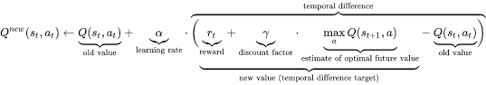

Q Learning is a off policy or model free reinforcement learning model. Simply put, Q learning tries to maximize the reward by finding the best action in a given state. There are many variations of this algorithm including double q-learning and gradient approximation versions such as Deep Q networks and this notebook will only implement the basic version.

[Wikiepdia - Q Learning](https://en.wikipedia.org/wiki/Q-learning)

The code below is a class implementation of the naive q learning algorithm. The constructor has all of the main hyperparamters and atari game interested in playing with. The methods here are to generate a model given number of episodes, mp4 visualization, and plot of cumulative reward over a given episode.

```python
class q_learning:
  """ Basic Naive Q Learning Algorithm

  Attributes:
      alpha: Learning rate for Q Learning, higher better in the beginning
      gamma: Discounting factor for reward to balance future and intermediate rewards, should increase near the end for more immediate reward (not implemented)
      episilon: Episilon used for epislon greedy action selection algorithm, should decrease overtime as model should not need to expore much in future
      game: Game of Choice
  """
  def __init__(self, alpha = 0.618, gamma = 0.1, episilon = 0.1, game="MsPacman-v0"):
    self.alpha = alpha
    self.episilon = episilon
    self.gamma = gamma
    self.game = game
    self.folder_path = 'temp_' + str(uuid.uuid1())
    self.g_over_time = []

  def plot_g(self):
    """ Plot the G over all of the episodes """
    if len(self.g_over_time) != 0:
      episodes = [n for n in range(1, len(self.g_over_time) + 1)]
      plot_df = pd.DataFrame({'num_episode': episodes, 'g': self.g_over_time})
      return(sns.lineplot(data = plot_df, x = 'num_episode', y = 'g'))
    else:
      print("Please ")

  def show_video(self):
    """ Show last video recorded """
    mp4list = glob.glob(os.path.join(self.folder_path, '*.mp4'))
    if len(mp4list) > 0:
      mp4 = mp4list[-1] # Load the last video
      video = io.open(mp4, 'r+b').read()
      encoded = base64.b64encode(video)
      ipythondisplay.display(HTML(data='''<video alt="test" autoplay
                  loop controls style="height: 400px;">
                  <source src="data:video/mp4;base64,{0}" type="video/mp4" />
               </video>'''.format(encoded.decode('ascii'))))
    else:
      print("Could not find video")

  def wrap_env(self, env):
    """ Wrap environment to output video """
    # Make temp dir for a run
    if not os.path.exists(self.folder_path):
      os.makedirs(self.folder_path)

    env = Monitor(env, os.path.join('./', self.folder_path), force=True)
    return env

  def generate_trial(self, max_episodes = 100):
    """ Generate a trial based on number of max episodes

    Attributes:
      max_episodes: Max number of episodes to run
    """
    # Init openai gym and action values
    env = self.wrap_env(gym.make(self.game))
    Q = np.zeros([env.observation_space.high.shape[0] * env.observation_space.high.shape[1], env.action_space.n]) # States x actions
    self.g_over_time = [] # Reset

    # Run through all episodes to train our model
    for episode in range(1, max_episodes):
      done = False # Reset each try
      G, reward = 0,0 # Init rewards
      state = env.reset() # Need to reset the environment each finished episode

      while done != True:
        # Epsilon Greedy Algorithm to select action
        if random.uniform(0, 1) < self.episilon: # Randomly choose to explore based on episilon
          action =  env.action_space.sample()
        else:
          action = np.argmax(Q[state[:,:,0]]) # Greedy action aka action with highest action value

        # Take action and find out what happens in next state and get reward
        state_t_1, reward, done, info = env.step(action)
        Q[state[:,:,0],action] = Q[state[:,:,0],action] +  (self.alpha * (reward + (np.max(Q[state_t_1[:,:,0]])) - Q[state[:,:,0],action]))
        # Q[state[:,:,0],action] = Q[state[:,:,0],action] +  (self.alpha * (reward + (self.gamma * np.max(Q[state_t_1[:,:,0]])) - Q[state[:,:,0],action])) # Bug with argmax

        G += reward # Just for record keeping as total reward
        state = state_t_1 # Want to save current state as previous state to infer based on prior actions

      if episode % 10 == 0:
          print('Episode {} Total Reward: {}'.format(episode,G))

      self.g_over_time.append(G) # Save G overtime

    env.close() # Close recording and get last result
```

The following code will show examples with different hyperparameters and different games.

```python
test = q_learning()
test.generate_trial(50)
test.show_video()
```

```
Episode 10 Total Reward: 1060.0
Episode 20 Total Reward: 130.0
Episode 30 Total Reward: 300.0
Episode 40 Total Reward: 300.0
```

[video not shown]

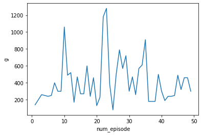

```python
test.plot_g()
```

## Air Raid Example

### 100 Episodes

```python
test3 = q_learning(game="AirRaid-v0")
test3.generate_trial(100)
test3.show_video()
```

```
Episode 10 Total Reward: 175.0
Episode 20 Total Reward: 375.0
Episode 30 Total Reward: 250.0
Episode 40 Total Reward: 450.0
Episode 50 Total Reward: 450.0
Episode 60 Total Reward: 100.0
Episode 70 Total Reward: 125.0
Episode 80 Total Reward: 200.0
Episode 90 Total Reward: 125.0
```

[video not shown]

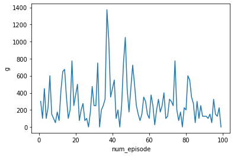

```python
test3.plot_g()
```

### 100 Episodes

```python
test4 = q_learning(game="BattleZone-v0")
test4.generate_trial(100)
test4.show_video()
```

```
Episode 10 Total Reward: 0.0
Episode 20 Total Reward: 3000.0
Episode 30 Total Reward: 1000.0
Episode 40 Total Reward: 8000.0
Episode 50 Total Reward: 2000.0
Episode 60 Total Reward: 4000.0
Episode 70 Total Reward: 3000.0
Episode 80 Total Reward: 0.0
Episode 90 Total Reward: 6000.0
```

[video not shown]

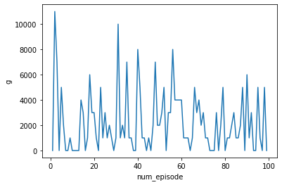

```python
test4.plot_g()
```

#### Lower learning rate

```python
test5 = q_learning(game="BattleZone-v0", alpha = 0.3)
test5.generate_trial(100)
test5.show_video()
```

```
Episode 10 Total Reward: 6000.0
Episode 20 Total Reward: 5000.0
Episode 30 Total Reward: 2000.0
Episode 40 Total Reward: 0.0
Episode 50 Total Reward: 3000.0
Episode 60 Total Reward: 3000.0
Episode 70 Total Reward: 0.0
Episode 80 Total Reward: 12000.0
Episode 90 Total Reward: 3000.0
```

[video not shown]

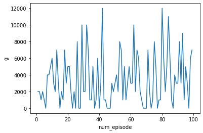

```python
test5.plot_g()
```

#### Higher randomness

```python
test6 = q_learning(game="BattleZone-v0", episilon = 0.6) # 60% time do random stuff
test6.generate_trial(50)
test6.show_video()
```

```
Episode 10 Total Reward: 2000.0
Episode 20 Total Reward: 2000.0
Episode 30 Total Reward: 2000.0
Episode 40 Total Reward: 1000.0
```

[video not shown]

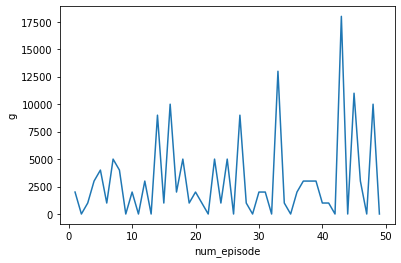

```python
test6.plot_g()
```